# EDA Exercises

Solutions

1/5/2018

## Solutions to EDA exercises

#### Load the data:

```r
cdc <- read.csv("data/cdc.csv")
```

#### Exercise 1:

```r
dim(cdc)
```

```
## [1] 20000     9
```

There are 20,000 cases (observations/rows) and 9 variables.

Categorical variables are labels, and quantitative variables are numeric measures on which basic arithmetic makes sense.

| Variable | Type |
| --- | --- |
| `genhlth` | categorical |
| `exerany` | categorical |
| `hlthplan` | categorical |
| `smoke100` | categorical |
| `height` | quantitative |
| `weight` | quantitative |
| `wtdesire` | quantitative |
| `age` | quantitative |
| `gender` | categorical |

#### Exercise 2:

Numerical summaries summary for `height` and `age`

```r
summary(cdc$height)
```

```
##    Min. 1st Qu.  Median    Mean 3rd Qu.    Max.
##   48.00   64.00   67.00   67.18   70.00   93.00
```

```r
IQR(cdc$height)
```

```
## [1] 6
```

```r
summary(cdc$age)
```

```
##    Min. 1st Qu.  Median    Mean 3rd Qu.    Max.
##   18.00   31.00   43.00   45.07   57.00   99.00
```

```r
IQR(cdc$age)
```

```
## [1] 26
```

Relative frequency distributions for `gender` and `exerany`

```r
table(cdc$gender)
```

```
##
##     f     m
## 10431  9569
```

There are 9,569 males in the sample.

```r
table(cdc$exerany)
```

```
##
##     0     1
##  5086 14914
```

```r
table(cdc$genhlth)
```

```
##
## excellent      fair      good      poor very good
##      4657      2019      5675       677      6972
```

$4657/20000$ (or 23.285%) of the sample reports being in excellent health.

#### Exercise 3:

```r
under23_and_smoke <- subset(cdc, age < 23 & smoke100 == 1)
dim(under23_and_smoke)
```

```
## [1] 620   9
```

#### Exercise 4:

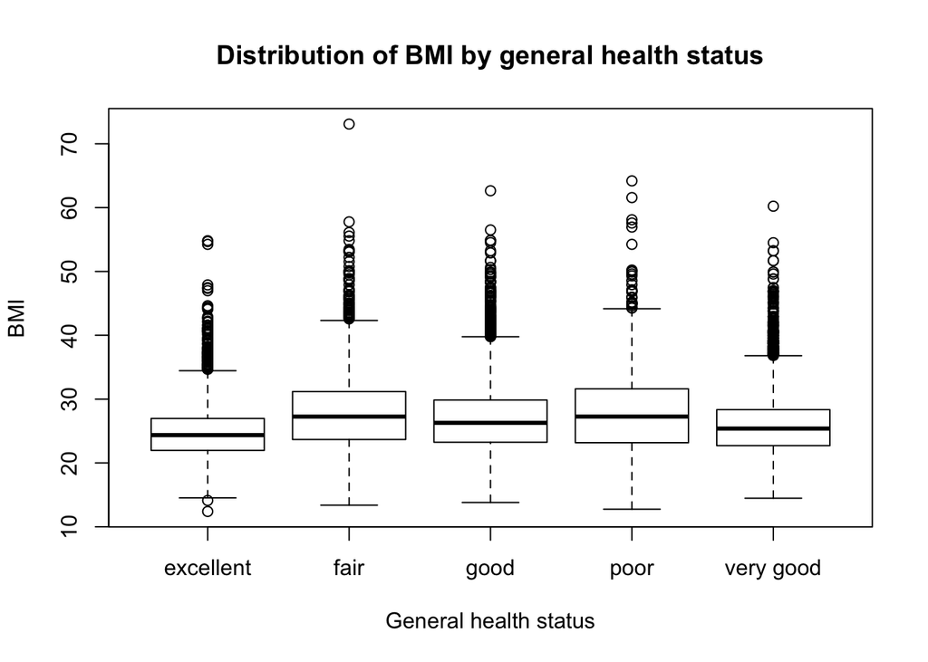

```r
cdc <- transform(cdc, bmi = (weight / height^2) * 703)
boxplot(cdc$bmi ~ cdc$genhlth, xlab = "General health status", ylab = "BMI",
        main = "Distribution of BMI by general health status")
```

Note: I was asked how to reorder the levels of this factor in class. I will go over this at some point in class, but here is the command:

```r
cdc$genhlth <- factor(cdc$genhlth, levels = c("excellent", "very good", "good", "fair", "poor"))
```

Now let’s recreate the boxplots to see if it worked:

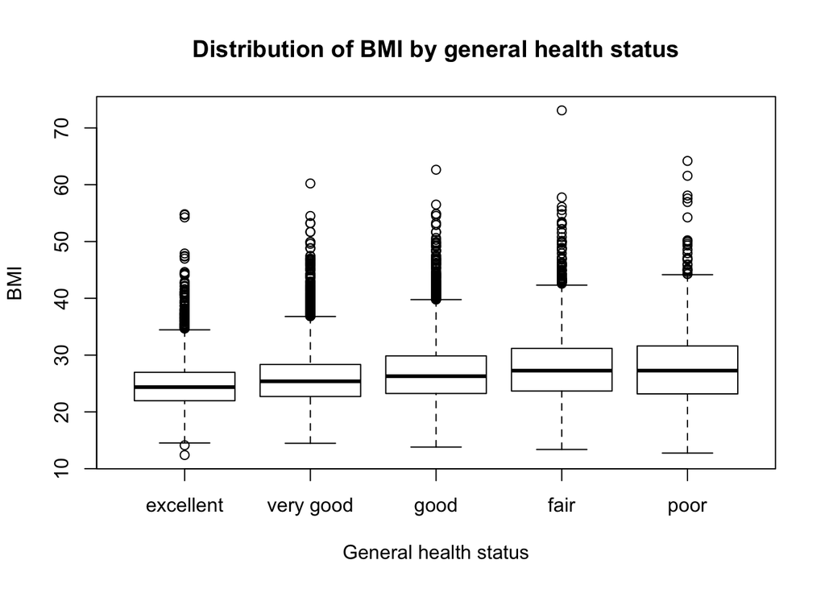

```r
boxplot(cdc$bmi ~ cdc$genhlth, xlab = "General health status", ylab = "BMI",
        main = "Distribution of BMI by general health status")
```

Most BMIs are roughly between 20 and 30 (over 50% of the data in the “healthier” groups and about 50% in the fair and poor health groups). We see the median BMI trending upward as health declines. Additionally, the IQRs seem to increase as health declines (i.e. BMIs are more variable).

#### Exercise 5:

```r
tapply(cdc$weight, INDEX = cdc$genhlth, FUN = mean)
```

```
## excellent very good      good      fair      poor
##  162.2289  169.2114  173.2141  176.1778  176.8449
```

```r
tapply(cdc$weight, INDEX = cdc$genhlth, FUN = sd)
```

```
## excellent very good      good      fair      poor
##  34.75060  38.07913  42.01465  45.74420  50.26219
```

### On your own:

#### 1:

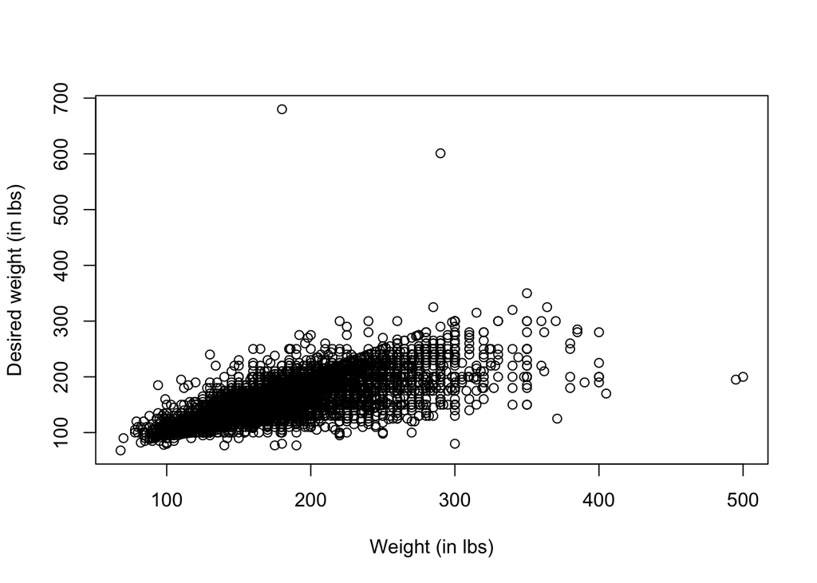

```r
plot(cdc$weight, cdc$wtdesire, xlab = "Weight (in lbs)", ylab = "Desired weight (in lbs)")
```

There is a positive linear relationship between weight and desired weight. There are two very large outliers indicating that individuals desire to weight 600 or 700 pounds. Perhaps these are data recording errors. Additionally, we see some individuals that weight approximately 500 pounds that want desire to weight approximately 200 pounds (this seems more reasonable).

#### 2:

```r
cdc <- transform(cdc, wdiff = wtdesire - weight)
head(cdc) # checking that is worked
```

```
##     genhlth exerany hlthplan smoke100 height weight wtdesire age gender
## 1      good       0        1        0     70    175      175  77      m
## 2      good       0        1        1     64    125      115  33      f
## 3      good       1        1        1     60    105      105  49      f
## 4      good       1        1        0     66    132      124  42      f
## 5 very good       0        1        0     61    150      130  55      f
## 6 very good       1        1        0     64    114      114  55      f
##        bmi wdiff
## 1 25.10714     0
## 2 21.45386   -10
## 3 20.50417     0
## 4 21.30303    -8
## 5 28.33916   -20
## 6 19.56592     0
```

#### 3:

`wdiff` is a quantitative variable. If the observed value is 0, then the person’s current and desired weight are equal. Negative values of `wdiff` indicate that the individual wants to lose weight, while positive values indicate that they want to gain weight

#### 4:

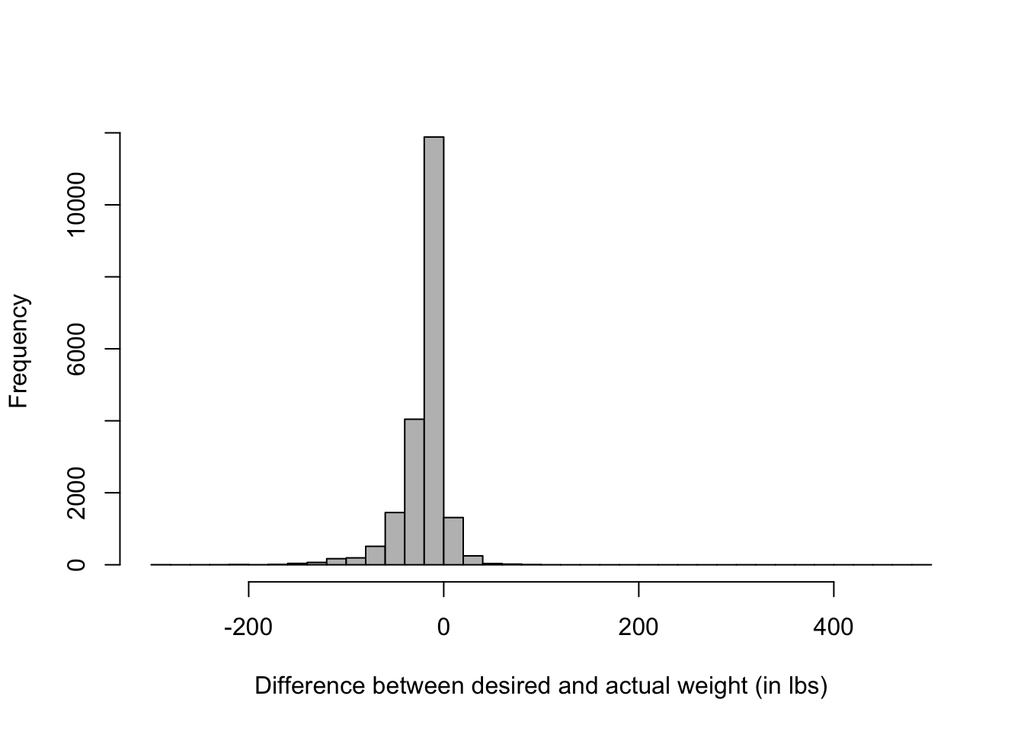

```r
# Histogram
hist(cdc$wdiff, col = "gray", breaks = 50, xlab = "Difference between desired and actual weight (in lbs)", main = NULL)
```

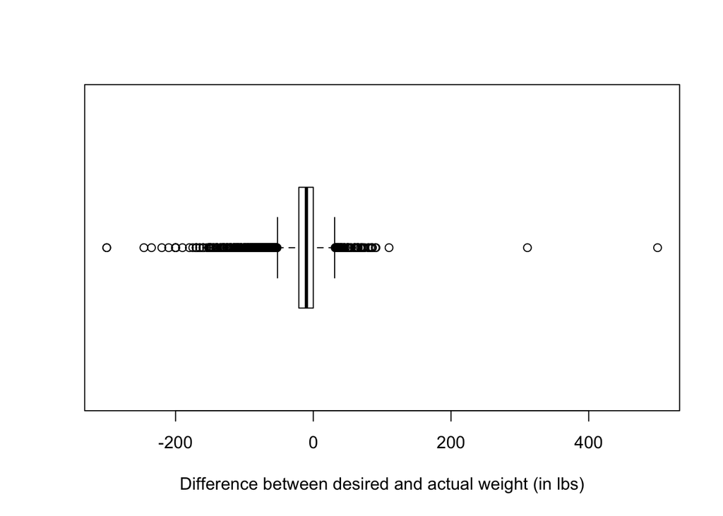

```r
# Boxplot (notice that I fliped the axes here)
boxplot(cdc$wdiff, horizontal = TRUE, xlab = "Difference between desired and actual weight (in lbs)")
```

The boxplot highlights the outliers, especially the two overly extreme positive outliers.

```r
# Looking at summary statistics
summary(cdc$wdiff)
```

```
##    Min. 1st Qu.  Median    Mean 3rd Qu.    Max.
## -300.00  -21.00  -10.00  -14.59    0.00  500.00
```

```r
sd(cdc$wdiff)
```

```
## [1] 24.04586
```

#### 5:

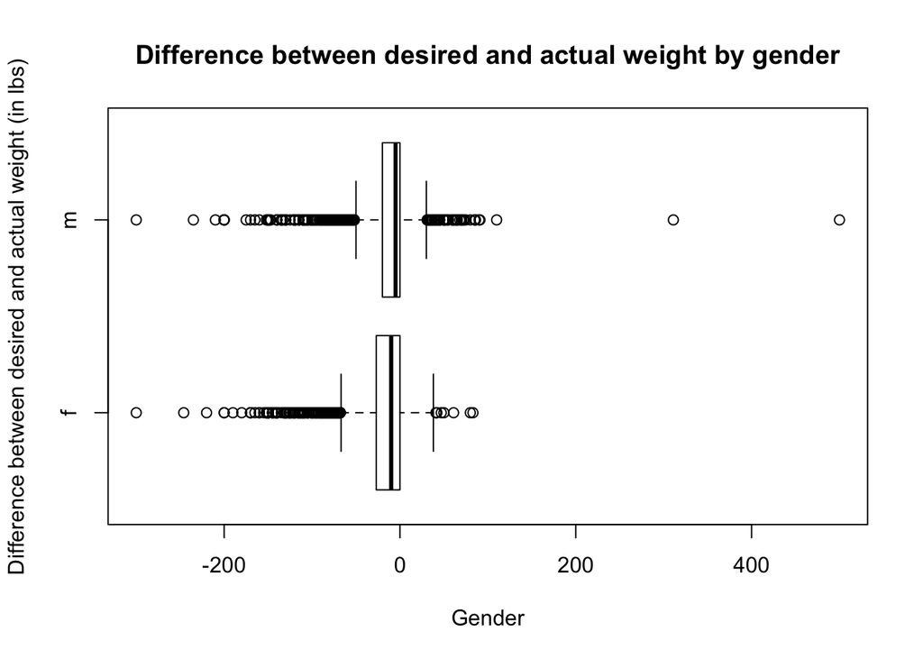

```r
boxplot(cdc$wdiff ~ cdc$gender, xlab = "Gender", ylab = "Difference between desired and actual weight (in lbs)", main = "Difference between desired and actual weight by gender", horizontal = TRUE)
```

```r
tapply(cdc$wdiff, INDEX = cdc$gender, FUN = summary)
```

```
## $f
##    Min. 1st Qu.  Median    Mean 3rd Qu.    Max.
## -300.00  -27.00  -10.00  -18.15    0.00   83.00
##
## $m
##    Min. 1st Qu.  Median    Mean 3rd Qu.    Max.
## -300.00  -20.00   -5.00  -10.71    0.00  500.00
```

#### 6:

My approach to this problem is to create new objects to store the mean (`xbar`) and standard deviation (`s`), create a new variable that is `TRUE` if the weight is within one standard deviation of the mean and `FALSE` otherwise. Then, taking the mean yields the proportion since `TRUE` is interpreted as a `1` and `FALSE` is interpreted as a `0`.

```r
# Summary stats
xbar <- mean(cdc$weight)
s <- sd(cdc$weight)


# Creating a TRUE/FALSE variable for being with one sd of the mean
cdc <- transform(cdc, one_sd_weight = weight >= xbar - s & weight <= xbar + s)

# Now you can take the mean of TRUE/FALSE (TRUE = 1, FALSE = 0)
mean(cdc$one_sd_weight)
```

```
## [1] 0.7076
```

70.76% of the weights are within one standard deviation of the mean.